# R Notebook

#### Load frequently used packages

```r
library(skimr)
library(openxlsx)
library(ggrepel)
library(dplyr)
library(tidyr)
library(data.table)
library(broom)
library(broomExtra)
library(tibble)
library(sjstats)
library(car)
#library(lme4)
#library(lmerTest)
library(ggplot2)
library(tibble)
library(modelr)
library(tidyverse)
#library(miceadds)
library(ggforce)
require(openxlsx)
library(tidyverse)
library(caret)
#library(glmnet)
library(ggplot2)
library(gridExtra)
library(MASS) # rlm
library(lmPerm)
library(circlize)
library(RColorBrewer)
library(ComplexHeatmap)
select <- dplyr::select
filter <- dplyr::filter
`%notin%` <- Negate(`%in%`)

library(illuminaio)
library(IlluminaDataTestFiles)
#install.packages("scales")
library(scales)
```

#### Define the directories used in this script

```r
dir.IlluminaProductFiles <- "/Users/shawjes/Dropbox/EspinosaGroup/DATA_MAIN/MEGA/chr21_genotyping/Illumina_ProductFiles"
dir.chr21_genotyping <- "/Users/shawjes/Dropbox/EspinosaGroup/DATA_MAIN/MEGA/chr21_genotyping"
dir.chr21_idatQuants <- "/Users/shawjes/Dropbox/EspinosaGroup/DATA_MAIN/MEGA/chr21_genotyping/idatQuants"
dir.GRSdata <- "/Users/shawjes/Dropbox/EspinosaGroup/ANALYSIS/Celiac_MultiOmics/GRS/DSMIG_Shared/Manuscript_Figure1/Data"
```

#### Print session info for reproducibility

```r
save.sessionInfo <- sessionInfo()

setwd(dir.GRSdata)
saveRDS(save.sessionInfo, "MEGA_042022_sessionInfo_chr21_rs1893592_manual_genotyping_v0.1_JRS.rds")
```

```r
HTP.idatData[[1]] %>% names()
```

```
[1] "idatID"         "Barcode"        "Quants_rowname" "Mean"           "SD"             "NBeads"
```

```r
HTP.idatData[[1]]
```

| idatID | Barcode | Quants_rowname | Mean | SD | NBeads |
| --- | --- | --- | --- | --- | --- |
| ./203752160105/203752160105_R06C01_Red.idat | 203752160105 | 1600105 | 19736 | 2516 | 17 |
| ./203752160105/203752160105_R06C01_Red.idat | 203752160105 | 1600109 | 1334 | 807 | 25 |
| ./203752160105/203752160105_R06C01_Red.idat | 203752160105 | 1600113 | 31751 | 3020 | 10 |
| ./203752160105/203752160105_R06C01_Red.idat | 203752160105 | 1600115 | 567 | 351 | 9 |
| ./203752160105/203752160105_R06C01_Red.idat | 203752160105 | 1600119 | 12423 | 1419 | 14 |
| ./203752160105/203752160105_R06C01_Red.idat | 203752160105 | 1600123 | 12978 | 1831 | 19 |
| ./203752160105/203752160105_R06C01_Red.idat | 203752160105 | 1600131 | 14688 | 1932 | 19 |
| ./203752160105/203752160105_R06C01_Red.idat | 203752160105 | 1600139 | 897 | 593 | 24 |
| ./203752160105/203752160105_R06C01_Red.idat | 203752160105 | 1600141 | 4415 | 1363 | 22 |
| ./203752160105/203752160105_R06C01_Red.idat | 203752160105 | 1600163 | 1596 | 601 | 6 |

[output cut: 990 more lines]

#### Copy Illumina product files to the GRS analysis data directory

```bash
# cp -a /source/. /dest/

cp -a '/Users/shawjes/Dropbox/EspinosaGroup/DATA_MAIN/MEGA/chr21_genotyping/Illumina_ProductFiles' '/Users/shawjes/Dropbox/EspinosaGroup/ANALYSIS/Celiac_MultiOmics/GRS/DSMIG_Shared/Manuscript_Figure1/Data/'

cp -a '/Users/shawjes/Dropbox/EspinosaGroup/DATA_MAIN/MEGA/031422_Proton_to_Local/GenomeStudio/Espinosa_MEGA2_08122019_Final.csv' '/Users/shawjes/Dropbox/EspinosaGroup/ANALYSIS/Celiac_MultiOmics/GRS/DSMIG_Shared/Manuscript_Figure1/Data/'
```

#### Read in the Illumina product file manifest for MEGA

```r
setwd(paste(dir.GRSdata, "/Illumina_ProductFiles", sep = ""))
productFile.manifest <- fread("Multi-EthnicGlobal_D1.csv", skip = 7)
```

```
|--------------------------------------------------|
|==================================================|
Warning in fread("Multi-EthnicGlobal_D1.csv", skip = 7) :
  Stopped early on line 1748259. Expected 21 fields but found 1. Consider fill=TRUE and comment.char=. First discarded non-empty line: <<[Controls]>>
```

```r
productFile.manifest
```

| IlmnID | Name | IlmnStrand | SNP | AddressA_ID | AlleleA_ProbeSeq | AddressB_ID | AlleleB_ProbeSeq | GenomeBuild | Chr | MapInfo | Ploidy | Species | Source | SourceVersion | SourceStrand | SourceSeq | TopGenomicSeq | BeadSetID | Exp_Clusters | RefStrand |
| --- | --- | --- | --- | --- | --- | --- | --- | --- | --- | --- | --- | --- | --- | --- | --- | --- | --- | --- | --- | --- |
| 10:100012219-GT-0_B_F_2298934103 | 10:100012219-GT | BOT | [T/G] | 22775276 | GAGCCATTGAGAGTGAGGAGGTCGTAGTGGGTGAAGACCTCAATGCTGTG | NA |  | 37 | 10 | 100012219 | diploid | Homo sapiens | PAGE | 0 | BOT | GCCACCTTGGAGCCATTGAGAGTGAGGAGGTCGTAGTGGGTGAAGACCTCAATGCTGTG[T/G]TAATGCCTGCAGAAGGGGTAGAGCTGTCAGTGCGGCAGCAACAGGAGAGGGTCCTCTCT | AGAGAGGACCCTCTCCTGTTGCTGCCGCACTGACAGCTCTACCCCTTCTGCAGGCATTA[A/C]CACAGCATTGAGGTCTTCACCCACTACGACCTCCTCACTCTCAATGGCTCCAAGGTGGC | 1067 | 3 | + |
| 10:100013340-CT-0_T_R_2299260687 | 10:100013340-CT | TOP | [A/G] | 44634128 | CACACAGATCTACAATCTGGGCCGGACTGACTTTCGTCCAAAGACTGGAC | NA |  | 37 | 10 | 100013340 | diploid | Homo sapiens | PAGE | 0 | BOT | CTAGTGCCAATGCATGGGCAGGCTCTAACCTGTGGCACTGGTGCCAAACCCAGCTATCG[T/C]GTCCAGTCTTTGGACGAAAGTCAGTCCGGCCCAGATTGTAGATCTGTGTGGAGAAGCGC | GCGCTTCTCCACACAGATCTACAATCTGGGCCGGACTGACTTTCGTCCAAAGACTGGAC[A/G]CGATAGCTGGGTTTGGCACCAGTGCCACAGGTTAGAGCCTGCCCATGCATTGGCACTAG | 1067 | 3 | - |
| 10:100013459-TCTC-T-0_M_R_2301504613 | 10:100013459-TCTC-T | MINUS | [D/I] | 5686381 | CGGCCTACTTGGAGGACCGCCCGCTCAGCCAGCTGTATTGTGCCCACGAG | NA |  | 37 | 10 | 100013459 | diploid | Homo sapiens | PAGE | 0 | PLUS | CAATAGGCGGCGGTATCCGTAGGGCCAGTCCATGTGATCCGCAGACTTGGAGAGGCAGTT[-/CTC]CTCGTGGGCACAATACAGCTGGCTGAGCGGGCGGTCCTCCAAGTAGGCCGTCTCCTGCA | CAATAGGCGGCGGTATCCGTAGGGCCAGTCCATGTGATCCGCAGACTTGGAGAGGCAGTT[-/CTC]CTCGTGGGCACAATACAGCTGGCTGAGCGGGCGGTCCTCCAAGTAGGCCGTCTCCTGCA | 1067 | 3 | - |
| 10:100013467-GA-0_T_F_2299260694 | 10:100013467-GA | TOP | [A/G] | 69618863 | GTAGGGCCAGTCCATGTGATCCGCAGACTTGGAGAGGCAGTTCTCCTCGT | NA |  | 37 | 10 | 100013467 | diploid | Homo sapiens | PAGE | 0 | TOP | GCGGTATCCGTAGGGCCAGTCCATGTGATCCGCAGACTTGGAGAGGCAGTTCTCCTCGT[A/G]GGCACAATACAGCTGGCTGAGCGGGCGGTCCTCCAAGTAGGCCGTCTCCTGCACTAGCT | GCGGTATCCGTAGGGCCAGTCCATGTGATCCGCAGACTTGGAGAGGCAGTTCTCCTCGT[A/G]GGCACAATACAGCTGGCTGAGCGGGCGGTCCTCCAAGTAGGCCGTCTCCTGCACTAGCT | 1067 | 3 | + |
| 10:100015474-GA-0_B_R_2299260701 | 10:100015474-GA | BOT | [T/C] | 67800195 | GACTGGGTGACGCTGGCTGTCTTCTTAGGAAACCTGGTTCTGGTCGGGGA | NA |  | 37 | 10 | 100015474 | diploid | Homo sapiens | PAGE | 0 | TOP | GGGCCAGCTCTGTGCCTGAGCAGCGCACCCCACTCATCACCACCTCCTGGGCCCTTGGC[A/G]TCCCCGACCAGAACCAGGTTTCCTAAGAAGACAGCCAGCGTCACCCAGTCAGCGTGcct | GGGCCAGCTCTGTGCCTGAGCAGCGCACCCCACTCATCACCACCTCCTGGGCCCTTGGC[A/G]TCCCCGACCAGAACCAGGTTTCCTAAGAAGACAGCCAGCGTCACCCAGTCAGCGTGcct | 1067 | 3 | - |
| 10:100016685-CT-0_B_F_2299260702 | 10:100016685-CT | BOT | [T/C] | 67673224 | GGACCCCGTTCACCTCCACCTGCACCTCCAATAGCCCCTCCTCAGGGATA | NA |  | 37 | 10 | 100016685 | diploid | Homo sapiens | PAGE | 0 | BOT | CCCAGCGTGGGACCCCGTTCACCTCCACCTGCACCTCCAATAGCCCCTCCTCAGGGATA[T/C]GCCCACCAGCCAAGCGCACCTGCAATGGCGAGGGGTGTGTGAGGAgtggggtagccttg | caaggctaccccacTCCTCACACACCCCTCGCCATTGCAGGTGCGCTTGGCTGGTGGGC[A/G]TATCCCTGAGGAGGGGCTATTGGAGGTGCAGGTGGAGGTGAACGGGGTCCCACGCTGGG | 1067 | 3 | + |
| 10:100017801-CT-0_T_R_2299260721 | 10:100017801-CT | TOP | [A/G] | 40782285 | AGTGGGGCACGGTCTGTGACCACAGGTGGAACCTCATCTCTGCCAGTGTC | NA |  | 37 | 10 | 100017801 | diploid | Homo sapiens | PAGE | 0 | BOT | GCCCAGCCGGGCCCCAAAGAGGGCCTCCCGAGCAGAGCCAAAGCCCAGCTGACGACACA[T/C]GACACTGGCAGAGATGAGGTTCCACCTGTGGTCACAGACCGTGCCCCACTGGCGGTTCA | TGAACCGCCAGTGGGGCACGGTCTGTGACCACAGGTGGAACCTCATCTCTGCCAGTGTC[A/G]TGTGTCGTCAGCTGGGCTTTGGCTCTGCTCGGGAGGCCCTCTTTGGGGCCCGGCTGGGC | 1067 | 3 | - |
| 10:100017854-CT-0_B_F_2299260722 | 10:100017854-CT | BOT | [T/C] | 20630905 | CACTGGCAGAGATGAGGTTCCACCTGTGGTCACAGACCGTGCCCCACTGG | NA |  | 37 | 10 | 100017854 | diploid | Homo sapiens | PAGE | 0 | BOT | GACACACGACACTGGCAGAGATGAGGTTCCACCTGTGGTCACAGACCGTGCCCCACTGG[T/C]GGTTCATGAGCACTTCCACCCGGCCCTCGCCCACCTGGGCCCCGGAGCGCAGGCGCACC | GGTGCGCCTGCGCTCCGGGGCCCAGGTGGGCGAGGGCCGGGTGGAAGTGCTCATGAACC[A/G]CCAGTGGGGCACGGTCTGTGACCACAGGTGGAACCTCATCTCTGCCAGTGTCGTGTGTC | 1067 | 3 | + |
| 10:100020695-CT-0_B_F_2299260732 | 10:100020695-CT | BOT | [T/C] | 25765197 | CCTCCTGTGGGGCCTACGCCAGCCGCCCTCCTACCTGTAGTAGTGGCTGT | NA |  | 37 | 10 | 100020695 | diploid | Homo sapiens | PAGE | 0 | BOT | ACAACCCTGCCTCCTGTGGGGCCTACGCCAGCCGCCCTCCTACCTGTAGTAGTGGCTGT[T/C]GACAGGCACCTCGCTGGGGAAGCCCAGCATCCCGCACACCACCCTGCTGTTGTTCATGG | CCATGAACAACAGCAGGGTGGTGTGCGGGATGCTGGGCTTCCCCAGCGAGGTGCCTGTC[A/G]ACAGCCACTACTACAGGTAGGAGGGCGGCTGGCGTAGGCCCCACAGGAGGCAGGGTTGT | 1067 | 3 | + |
| 10:100020778-CT-0_B_F_2299260736 | 10:100020778-CT | BOT | [T/C] | 54800117 | CGCACACCACCCTGCTGTTGTTCATGGTCCAGCCCTGGTCACACACCTGC | NA |  | 37 | 10 | 100020778 | diploid | Homo sapiens | PAGE | 0 | BOT | CCAGCATCCCGCACACCACCCTGCTGTTGTTCATGGTCCAGCCCTGGTCACACACCTGC[T/C]GCCAGTGGCCCTCATACTTCACCTCCACGGCTCCCTCGGTCACTGGGCTATGCTGCTTG | CAAGCAGCATAGCCCAGTGACCGAGGGAGCCGTGGAGGTGAAGTATGAGGGCCACTGGC[A/G]GCAGGTGTGTGACCAGGGCTGGACCATGAACAACAGCAGGGTGGTGTGCGGGATGCTGG | 1067 | 3 | + |

[output cut: 990 more lines]

```r
productFile.manifest %>% filter(!is.na(AddressB_ID))
```

| IlmnID | Name | IlmnStrand | SNP | AddressA_ID | AlleleA_ProbeSeq | AddressB_ID | AlleleB_ProbeSeq | GenomeBuild | Chr | MapInfo | Ploidy | Species | Source | SourceVersion | SourceStrand | SourceSeq | TopGenomicSeq | BeadSetID | Exp_Clusters | RefStrand |
| --- | --- | --- | --- | --- | --- | --- | --- | --- | --- | --- | --- | --- | --- | --- | --- | --- | --- | --- | --- | --- |
| 10:100219482-A-T-0_T_R_2304259596 | 10:100219482-A-T | TOP | [A/T] | 75718377 | AATAATGAGTCCCATACTGTTTTTCCTCACTGTAGGTCAGTGCAACTGAA | 4749982 | AATAATGAGTCCCATACTGTTTTTCCTCACTGTAGGTCAGTGCAACTGAT | 37 | 10 | 100219482 | diploid | Homo sapiens | PAGE | 0 | BOT | GGGGGCGGGGCTTCAATTCTGGGAGGGTCCCGTCGTCCACCATCACTAAGGGCTGGCCA[A/T]TCAGTTGCACTGACCTACAGTGAGGAAAAACAGTATGGGACTCATTATTGCATTATAAG | CTTATAATGCAATAATGAGTCCCATACTGTTTTTCCTCACTGTAGGTCAGTGCAACTGA[A/T]TGGCCAGCCCTTAGTGATGGTGGACGACGGGACCCTCCCAGAATTGAAGCCCCGCCCCC | 1080 | 3 | - |
| 10:100374334-G-C-0_B_R_2315707249 | 10:100374334-G-C | BOT | [G/C] | 79639328 | ATTTGTATATTTATTACTATTGTTTTAACAATCCAGGCCGGGCACGGTGG | 77738563 | ATTTGTATATTTATTACTATTGTTTTAACAATCCAGGCCGGGCACGGTGC | 37 | 10 | 100374334 | diploid | Homo sapiens | PAGE | 0 | TOP | tcctgacctcgtgatccacccgccttggcctcccaaagtgctgagattacaggcgtgag[C/G]caccgtgcccggccTGGATTGTTAAAACAATAGTAataaatatacaaatatatataaat | tcctgacctcgtgatccacccgccttggcctcccaaagtgctgagattacaggcgtgag[C/G]caccgtgcccggccTGGATTGTTAAAACAATAGTAataaatatacaaatatatataaat | 1165 | 3 | - |
| 10:101558634-A-T-0_T_R_2304289384 | 10:101558634-A-T | TOP | [A/T] | 80616410 | AGTCCTGAGAGTGAAGGGCCTGGGCATGATGCTGAGAGGTCCTTTCTGTA | 94778455 | AGTCCTGAGAGTGAAGGGCCTGGGCATGATGCTGAGAGGTCCTTTCTGTT | 37 | 10 | 101558634 | diploid | Homo sapiens | PAGE | 0 | BOT | gggatacaattcaacccataacaTCTCACAGCAACCATGAAAAGAACAAGCATGAAAAG[A/T]ACAGAAAGGACCTCTCAGCATCATgcccaggcccttcactctcaggactgcccctcagg | cctgaggggcagtcctgagagtgaagggcctgggcATGATGCTGAGAGGTCCTTTCTGT[A/T]CTTTTCATGCTTGTTCTTTTCATGGTTGCTGTGAGAtgttatgggttgaattgtatccc | 1080 | 3 | - |
| 10:101567988-T-A-0_T_R_2304259608 | 10:101567988-T-A | TOP | [A/T] | 19774220 | CCAAGGCTTTTAACCAGAGACAGGGAGTTAGCAGTGAGAATGCCGACCTA | 19740290 | CCAAGGCTTTTAACCAGAGACAGGGAGTTAGCAGTGAGAATGCCGACCTT | 37 | 10 | 101567988 | diploid | Homo sapiens | PAGE | 0 | BOT | CAATATCCTGCGCTTTCCCCTGAGCATGCTTCCCATGATGATCTCCTCCATGCTCCAGG[A/T]AGGTCGGCATTCTCACTGCTAACTCCCTGTCTCTGGTTAAAAGCCTTGGAGTCCAGAAT | ATTCTGGACTCCAAGGCTTTTAACCAGAGACAGGGAGTTAGCAGTGAGAATGCCGACCT[A/T]CCTGGAGCATGGAGGAGATCATCATGGGAAGCATGCTCAGGGGAAAGCGCAGGATATTG | 1080 | 3 | - |
| 10:101595950-A-T-0_T_F_2304259617 | 10:101595950-A-T | TOP | [A/T] | 4650979 | GTCCCCAATCTACTCTCACTTCAGCGAGACCGTATCAGGTTTGCCAGTTA | 14773901 | GTCCCCAATCTACTCTCACTTCAGCGAGACCGTATCAGGTTTGCCAGTTT | 37 | 10 | 101595950 | diploid | Homo sapiens | PAGE | 0 | TOP | CTGTCACCAGGTCCCCAATCTACTCTCACTTCAGCGAGACCGTATCAGGTTTGCCAGTT[A/T]TCCGTGCCTTTGAGCACCAGCAGCGATTTCTGAAACACAATGAGGTGAGGATTGACACC | CTGTCACCAGGTCCCCAATCTACTCTCACTTCAGCGAGACCGTATCAGGTTTGCCAGTT[A/T]TCCGTGCCTTTGAGCACCAGCAGCGATTTCTGAAACACAATGAGGTGAGGATTGACACC | 1080 | 3 | + |
| 10:101620771-C-G-0_T_R_2304289408 | 10:101620771-C-G | TOP | [C/G] | 21684536 | ACATTGGAGAGGTTTGAGGTCCAAATCAAGGAATTTCAATTTGAGGAGTC | 21742879 | ACATTGGAGAGGTTTGAGGTCCAAATCAAGGAATTTCAATTTGAGGAGTG | 37 | 10 | 101620771 | diploid | Homo sapiens | PAGE | 0 | BOT | GCTATTTAGCTTTCTTAAAACAGGTCATCCCCTTAAAAACTTATGGGAGTTGATTACCT[C/G]ACTCCTCAAATTGAAATTCCTTGATTTGGACCTCAAACCTCTCCAATGTATTGTTTGTG | CACAAACAATACATTGGAGAGGTTTGAGGTCCAAATCAAGGAATTTCAATTTGAGGAGT[C/G]AGGTAATCAACTCCCATAAGTTTTTAAGGGGATGACCTGTTTTAAGAAAGCTAAATAGC | 1080 | 3 | - |
| 10:101755351-G-C-0_B_R_2315707311 | 10:101755351-G-C | BOT | [G/C] | 62737967 | CCAGCACTTCAAAGCTCACCCCATGAAATGCCCCCAACAAGCCTGTTTGG | 74735532 | CCAGCACTTCAAAGCTCACCCCATGAAATGCCCCCAACAAGCCTGTTTGC | 37 | 10 | 101755351 | diploid | Homo sapiens | PAGE | 0 | TOP | cacCAAAATACTGGCAGGGGAATCTAGGAAAAAGACATCCAATTTTGTTTAAGTCATGA[C/G]CAAACAGGCTTGTTGGGGGCATTTCATGGGGTGAGCTTTGAAGTGCTGGTGGGCCAGAG | cacCAAAATACTGGCAGGGGAATCTAGGAAAAAGACATCCAATTTTGTTTAAGTCATGA[C/G]CAAACAGGCTTGTTGGGGGCATTTCATGGGGTGAGCTTTGAAGTGCTGGTGGGCCAGAG | 1165 | 3 | - |
| 10:101919951-T-A-0_B_R_2315707317 | 10:101919951-T-A | BOT | [T/A] | 15795133 | ATCTATTGATTTAATTCCTGTATTGAGTATAGGTATATTCAGATACATGT | 46691535 | ATCTATTGATTTAATTCCTGTATTGAGTATAGGTATATTCAGATACATGA | 37 | 10 | 101919951 | diploid | Homo sapiens | PAGE | 0 | TOP | cagatgaaatgaacaattttctatgaaaatataattaccaaaactggcttaaaaagaaa[A/T]catgtatctgaatatacctatactcaatacaggaattaaatcaatagattaactgttac | cagatgaaatgaacaattttctatgaaaatataattaccaaaactggcttaaaaagaaa[A/T]catgtatctgaatatacctatactcaatacaggaattaaatcaatagattaactgttac | 1165 | 3 | - |
| 10:102356710-A-T-0_B_F_2315707336 | 10:102356710-A-T | BOT | [T/A] | 17771266 | TTAGTAGAGACGAGGTTTCACCATGTTGGCCAGGCTGGTCTCGAACTCCT | 29654292 | TTAGTAGAGACGAGGTTTCACCATGTTGGCCAGGCTGGTCTCGAACTCCA | 37 | 0 | 0 | diploid | Homo sapiens | PAGE | 0 | BOT | ttttgtatttttagtagagacgaggtttcaccatgttggccaggctggtctcgaactcc[A/T]gacctcaggtgatccacctgcctcggcctcccaaagtgctgggattaccggcatgagtc | gactcatgccggtaatcccagcactttgggaggccgaggcaggtggatcacctgaggtc[A/T]ggagttcgagaccagcctggccaacatggtgaaacctcgtctctactaaaaatacaaaa | 1165 | 3 | + |
| 10:102591161-A-T-0_B_R_2315707343 | 10:102591161-A-T | BOT | [T/A] | 82768352 | TTATATTGGGAGTACACATTCAGAATTCTTTTGGCTGAGAGGGTGTATGT | 88642590 | TTATATTGGGAGTACACATTCAGAATTCTTTTGGCTGAGAGGGTGTATGA | 37 | 10 | 102591161 | diploid | Homo sapiens | PAGE | 0 | TOP | CTGGTGTTGGCTGTCTTGACCGCCAGCCTCCTAGAAGagtggccttcaaacttctttga[A/T]catacaccctctcagccaaaagaattctgaatgtgtactcccaatataagtatatttac | CTGGTGTTGGCTGTCTTGACCGCCAGCCTCCTAGAAGagtggccttcaaacttctttga[A/T]catacaccctctcagccaaaagaattctgaatgtgtactcccaatataagtatatttac | 1165 | 3 | - |

[output cut: 990 more lines]

#### Read in the strand report

```r
setwd(paste(dir.GRSdata, "/Illumina_ProductFiles", sep = ""))
productFile.strandReport <- fread("Multi-EthnicGlobal_D1_StrandReport_FDT.txt")
```

```
|--------------------------------------------------|
|==================================================|
```

```r
productFile.rsIDs <- fread("Multi-EthnicGlobal_D1_b150_rsids.txt")
#productFile.PopulationReport <- fread("Population Reports (MAF, Copy Numbers).

productFile.strandReport
```

| Index | SNP_Name | Ilmn_ID | Build | Chr | Coord | Forward_Seq | Forward_Allele1 | Forward_Allele2 | Design_Seq | Design_Allele1 | Design_Allele2 | Top_Seq | Top_AlleleA | Top_AlleleB |
| --- | --- | --- | --- | --- | --- | --- | --- | --- | --- | --- | --- | --- | --- | --- |
| 1 | 10:100012219-GT | 10:100012219-GT-0_B_F_2298934103 | 37 | 10 | 100012219 | GCCACCTTGGAGCCATTGAGAGTGAGGAGGTCGTAGTGGGTGAAGACCTCAATGCTGTG[T/G]TAATGCCTGCAGAAGGGGTAGAGCTGTCAGTGCGGCAGCAACAGGAGAGGGTCCTCTCT | T | G | GCCACCTTGGAGCCATTGAGAGTGAGGAGGTCGTAGTGGGTGAAGACCTCAATGCTGTG[T/G]TAATGCCTGCAGAAGGGGTAGAGCTGTCAGTGCGGCAGCAACAGGAGAGGGTCCTCTCT | T | G | AGAGAGGACCCTCTCCTGTTGCTGCCGCACTGACAGCTCTACCCCTTCTGCAGGCATTA[A/C]CACAGCATTGAGGTCTTCACCCACTACGACCTCCTCACTCTCAATGGCTCCAAGGTGGC | A | C |
| 2 | 10:100013340-CT | 10:100013340-CT-0_T_R_2299260687 | 37 | 10 | 100013340 | CTAGTGCCAATGCATGGGCAGGCTCTAACCTGTGGCACTGGTGCCAAACCCAGCTATCG[T/C]GTCCAGTCTTTGGACGAAAGTCAGTCCGGCCCAGATTGTAGATCTGTGTGGAGAAGCGC | T | C | GCGCTTCTCCACACAGATCTACAATCTGGGCCGGACTGACTTTCGTCCAAAGACTGGAC[A/G]CGATAGCTGGGTTTGGCACCAGTGCCACAGGTTAGAGCCTGCCCATGCATTGGCACTAG | A | G | GCGCTTCTCCACACAGATCTACAATCTGGGCCGGACTGACTTTCGTCCAAAGACTGGAC[A/G]CGATAGCTGGGTTTGGCACCAGTGCCACAGGTTAGAGCCTGCCCATGCATTGGCACTAG | A | G |
| 3 | 10:100013459-TCTC-T | 10:100013459-TCTC-T-0_M_R_2301504613 | 37 | 10 | 100013459 | CAATAGGCGGCGGTATCCGTAGGGCCAGTCCATGTGATCCGCAGACTTGGAGAGGCAGTT[-/CTC]CTCGTGGGCACAATACAGCTGGCTGAGCGGGCGGTCCTCCAAGTAGGCCGTCTCCTGCA | D | I | TGCAGGAGACGGCCTACTTGGAGGACCGCCCGCTCAGCCAGCTGTATTGTGCCCACGAG[-/GAG]AACTGCCTCTCCAAGTCTGCGGATCACATGGACTGGCCCTACGGATACCGCCGCCTATTG | D | I | CAATAGGCGGCGGTATCCGTAGGGCCAGTCCATGTGATCCGCAGACTTGGAGAGGCAGTT[-/CTC]CTCGTGGGCACAATACAGCTGGCTGAGCGGGCGGTCCTCCAAGTAGGCCGTCTCCTGCA | D | I |
| 4 | 10:100013467-GA | 10:100013467-GA-0_T_F_2299260694 | 37 | 10 | 100013467 | GCGGTATCCGTAGGGCCAGTCCATGTGATCCGCAGACTTGGAGAGGCAGTTCTCCTCGT[A/G]GGCACAATACAGCTGGCTGAGCGGGCGGTCCTCCAAGTAGGCCGTCTCCTGCACTAGCT | A | G | GCGGTATCCGTAGGGCCAGTCCATGTGATCCGCAGACTTGGAGAGGCAGTTCTCCTCGT[A/G]GGCACAATACAGCTGGCTGAGCGGGCGGTCCTCCAAGTAGGCCGTCTCCTGCACTAGCT | A | G | GCGGTATCCGTAGGGCCAGTCCATGTGATCCGCAGACTTGGAGAGGCAGTTCTCCTCGT[A/G]GGCACAATACAGCTGGCTGAGCGGGCGGTCCTCCAAGTAGGCCGTCTCCTGCACTAGCT | A | G |
| 5 | 10:100015474-GA | 10:100015474-GA-0_B_R_2299260701 | 37 | 10 | 100015474 | GGGCCAGCTCTGTGCCTGAGCAGCGCACCCCACTCATCACCACCTCCTGGGCCCTTGGC[A/G]TCCCCGACCAGAACCAGGTTTCCTAAGAAGACAGCCAGCGTCACCCAGTCAGCGTGcct | A | G | aggCACGCTGACTGGGTGACGCTGGCTGTCTTCTTAGGAAACCTGGTTCTGGTCGGGGA[T/C]GCCAAGGGCCCAGGAGGTGGTGATGAGTGGGGTGCGCTGCTCAGGCACAGAGCTGGCCC | T | C | GGGCCAGCTCTGTGCCTGAGCAGCGCACCCCACTCATCACCACCTCCTGGGCCCTTGGC[A/G]TCCCCGACCAGAACCAGGTTTCCTAAGAAGACAGCCAGCGTCACCCAGTCAGCGTGcct | A | G |
| 6 | 10:100016685-CT | 10:100016685-CT-0_B_F_2299260702 | 37 | 10 | 100016685 | CCCAGCGTGGGACCCCGTTCACCTCCACCTGCACCTCCAATAGCCCCTCCTCAGGGATA[T/C]GCCCACCAGCCAAGCGCACCTGCAATGGCGAGGGGTGTGTGAGGAgtggggtagccttg | T | C | CCCAGCGTGGGACCCCGTTCACCTCCACCTGCACCTCCAATAGCCCCTCCTCAGGGATA[T/C]GCCCACCAGCCAAGCGCACCTGCAATGGCGAGGGGTGTGTGAGGAgtggggtagccttg | T | C | caaggctaccccacTCCTCACACACCCCTCGCCATTGCAGGTGCGCTTGGCTGGTGGGC[A/G]TATCCCTGAGGAGGGGCTATTGGAGGTGCAGGTGGAGGTGAACGGGGTCCCACGCTGGG | A | G |
| 7 | 10:100017801-CT | 10:100017801-CT-0_T_R_2299260721 | 37 | 10 | 100017801 | GCCCAGCCGGGCCCCAAAGAGGGCCTCCCGAGCAGAGCCAAAGCCCAGCTGACGACACA[T/C]GACACTGGCAGAGATGAGGTTCCACCTGTGGTCACAGACCGTGCCCCACTGGCGGTTCA | T | C | TGAACCGCCAGTGGGGCACGGTCTGTGACCACAGGTGGAACCTCATCTCTGCCAGTGTC[A/G]TGTGTCGTCAGCTGGGCTTTGGCTCTGCTCGGGAGGCCCTCTTTGGGGCCCGGCTGGGC | A | G | TGAACCGCCAGTGGGGCACGGTCTGTGACCACAGGTGGAACCTCATCTCTGCCAGTGTC[A/G]TGTGTCGTCAGCTGGGCTTTGGCTCTGCTCGGGAGGCCCTCTTTGGGGCCCGGCTGGGC | A | G |
| 8 | 10:100017854-CT | 10:100017854-CT-0_B_F_2299260722 | 37 | 10 | 100017854 | GACACACGACACTGGCAGAGATGAGGTTCCACCTGTGGTCACAGACCGTGCCCCACTGG[T/C]GGTTCATGAGCACTTCCACCCGGCCCTCGCCCACCTGGGCCCCGGAGCGCAGGCGCACC | T | C | GACACACGACACTGGCAGAGATGAGGTTCCACCTGTGGTCACAGACCGTGCCCCACTGG[T/C]GGTTCATGAGCACTTCCACCCGGCCCTCGCCCACCTGGGCCCCGGAGCGCAGGCGCACC | T | C | GGTGCGCCTGCGCTCCGGGGCCCAGGTGGGCGAGGGCCGGGTGGAAGTGCTCATGAACC[A/G]CCAGTGGGGCACGGTCTGTGACCACAGGTGGAACCTCATCTCTGCCAGTGTCGTGTGTC | A | G |
| 9 | 10:100020695-CT | 10:100020695-CT-0_B_F_2299260732 | 37 | 10 | 100020695 | ACAACCCTGCCTCCTGTGGGGCCTACGCCAGCCGCCCTCCTACCTGTAGTAGTGGCTGT[T/C]GACAGGCACCTCGCTGGGGAAGCCCAGCATCCCGCACACCACCCTGCTGTTGTTCATGG | T | C | ACAACCCTGCCTCCTGTGGGGCCTACGCCAGCCGCCCTCCTACCTGTAGTAGTGGCTGT[T/C]GACAGGCACCTCGCTGGGGAAGCCCAGCATCCCGCACACCACCCTGCTGTTGTTCATGG | T | C | CCATGAACAACAGCAGGGTGGTGTGCGGGATGCTGGGCTTCCCCAGCGAGGTGCCTGTC[A/G]ACAGCCACTACTACAGGTAGGAGGGCGGCTGGCGTAGGCCCCACAGGAGGCAGGGTTGT | A | G |
| 10 | 10:100020778-CT | 10:100020778-CT-0_B_F_2299260736 | 37 | 10 | 100020778 | CCAGCATCCCGCACACCACCCTGCTGTTGTTCATGGTCCAGCCCTGGTCACACACCTGC[T/C]GCCAGTGGCCCTCATACTTCACCTCCACGGCTCCCTCGGTCACTGGGCTATGCTGCTTG | T | C | CCAGCATCCCGCACACCACCCTGCTGTTGTTCATGGTCCAGCCCTGGTCACACACCTGC[T/C]GCCAGTGGCCCTCATACTTCACCTCCACGGCTCCCTCGGTCACTGGGCTATGCTGCTTG | T | C | CAAGCAGCATAGCCCAGTGACCGAGGGAGCCGTGGAGGTGAAGTATGAGGGCCACTGGC[A/G]GCAGGTGTGTGACCAGGGCTGGACCATGAACAACAGCAGGGTGGTGTGCGGGATGCTGG | A | G |

[output cut: 990 more lines]

```r
productFile.rsIDs
```

| Name | RsID |
| --- | --- |
| 10:100012219-GT | rs140271302 |
| 10:100013340-CT | rs749482948 |
| 10:100013459-TCTC-T | rs746887705 |
| 10:100013467-GA | rs546902438 |
| 10:100015474-GA | rs149208138 |
| 10:100016685-CT | rs150077126 |
| 10:100017801-CT | rs376024211 |
| 10:100017854-CT | rs777191312 |
| 10:100020695-CT | rs752052276 |
| 10:100020778-CT | rs371417619 |

[output cut: 990 more lines]

#### For rs1893592 (A/C), determine which alleles are represented by the Illumina TOP ‘Allele A’ and ‘Allele B’

```r
productFile.strandReport.rs1893592 <- productFile.strandReport %>% filter(grepl("rs1893592", SNP_Name)==TRUE) %>%
  select(-c(Forward_Seq, Design_Seq, Top_Seq)) %>%
  select(SNP_Name, Ilmn_ID, Top_AlleleA, Top_AlleleB, Forward_Allele1, Forward_Allele2, everything())

productFile.strandReport.rs1893592
```

| SNP_Name | Ilmn_ID | Top_AlleleA | Top_AlleleB | Forward_Allele1 | Forward_Allele2 | Index | Build | Chr | Coord | Design_Allele1 | Design_Allele2 |
| --- | --- | --- | --- | --- | --- | --- | --- | --- | --- | --- | --- |
| rs1893592 | rs1893592-138_B_R_2264336221 | A | C | A | C | 1250654 | 37 | 21 | 43855067 | T | G |

```r
print("rs1893592: TOP Allele A: A, TOP Allele B: C")
```

```
[1] "rs1893592: TOP Allele A: A, TOP Allele B: C"
```

```r
print("rs1893592: FWD Allele 1: A, FWD Allele2: C")
```

```
[1] "rs1893592: FWD Allele 1: A, FWD Allele2: C"
```

#### Read MEGA sample manifest

```r
setwd(dir.GRSdata)
HTP.MEGA.manifest <- fread("/Users/shawjes/Dropbox/EspinosaGroup/DATA_MAIN/MEGA/031422_Proton_to_Local/GenomeStudio/Espinosa_MEGA2_08122019_Final.csv",
                       skip = 8)

HTP.MEGA.manifest
```

| Sample_ID | SentrixBarcode_A | SentrixPosition_A | Sample_Plate | Sample_Well | Sample_Group | Gender | Sample_Name | Replicate | Parent1 | Parent2 |
| --- | --- | --- | --- | --- | --- | --- | --- | --- | --- | --- |
| WG1-DNA_A01_NA19235 | 203752170071 | R01C01 | 1 | A01 | NA | Female | NA19235 | NA | NA | NA |
| WG1-DNA_B01_HTP0207A | 203752170071 | R02C01 | 1 | B01 | NA | Female | HTP0207A | NA | NA | NA |
| WG1-DNA_C01_HTP0207A | 203752170071 | R03C01 | 1 | C01 | NA | Female | HTP0207A | NA | NA | NA |
| WG1-DNA_D01_HTP0222A | 203752170071 | R04C01 | 1 | D01 | NA | Female | HTP0222A | NA | NA | NA |
| WG1-DNA_E01_HTP0442A | 203752170071 | R05C01 | 1 | E01 | NA | Female | HTP0442A | NA | NA | NA |
| WG1-DNA_F01_HTP0219A | 203752170071 | R06C01 | 1 | F01 | NA | Female | HTP0219A | NA | NA | NA |
| WG1-DNA_G01_HTP0465A | 203752170071 | R07C01 | 1 | G01 | NA | Female | HTP0465A | NA | NA | NA |
| WG1-DNA_H01_HTP0119A | 203752170071 | R08C01 | 1 | H01 | NA | Female | HTP0119A | NA | NA | NA |
| WG1-DNA_B02_HTP0223A | 203752170089 | R02C01 | 1 | B02 | NA | Male | HTP0223A | NA | NA | NA |
| WG1-DNA_C02_HTP0471A | 203752170089 | R03C01 | 1 | C02 | NA | Female | HTP0471A | NA | NA | NA |

[output cut: 234 more lines]

#### Figure out the idat identifier for the GRS SNP on chromosome 21

```r
productFile.manifest %>% filter(Name == "rs1893592")

# Possible identifiers to match with idat files:
# 29800833
# 2264336221
```

[output not shown]

#### Use the illuminaio package to read in the idat files and save them to an R data object

[output not shown]

[output cut: 478 more lines]

```r
HTP.idatData.29800833.rs1893592 <- list()
for ( i in 1:length(HTP.idatData) ){
  # idat_id <- idat_paths$partial_path[[i]]
  #
  # setwd("/Users/shawjes/Dropbox/EspinosaGroup/DATA_MAIN/MEGA/031422_Proton_to_Local/idats")
  # HTP.idat[[i]] <- try(readIDAT(idat_id))
  #
  # HTP.idatData[[i]] <- HTP.idat[[i]]$Quants %>%
  #   as.data.frame()%>%
  #   mutate(Barcode = HTP.idat[[i]]$Barcode) %>%
  #   rownames_to_column("Quants_rowname") %>%
  #   mutate(idatID = idat_id) %>%
  #   select(idatID, Barcode, everything())

  HTP.idatData.29800833.rs1893592[[i]] <- HTP.idatData[[i]] %>%
    filter(Quants_rowname == "29800833") %>%
    mutate(Name = "rs1893592")
}

HTP.idatData.29800833.rs1893592.ALL <- HTP.idatData.29800833.rs1893592 %>% rbindlist()

HTP.idatData.29800833.rs1893592.ALL



setwd(dir.chr21_idatQuants)
saveRDS(HTP.idatData.29800833.rs1893592, file = "MEGA_041422_idat_Quants_AddressA29800833_rs1893592_v0.1_JRS.rds")

setwd(dir.chr21_idatQuants)
fwrite(HTP.idatData.29800833.rs1893592.ALL, "MEGA_041422_idat_Quants_AddressA29800833_rs1893592_ALL_v0.1_JRS.csv.gz")

setwd(dir.GRSdata)
saveRDS(HTP.idatData.29800833.rs1893592, file = "MEGA_041422_idat_Quants_AddressA29800833_rs1893592_v0.1_JRS.rds")

setwd(dir.GRSdata)
fwrite(HTP.idatData.29800833.rs1893592.ALL, "MEGA_041422_idat_Quants_AddressA29800833_rs1893592_ALL_v0.1_JRS.csv.gz")
```

| idatID | Barcode | Quants_rowname | Mean | SD | NBeads | Name |
| --- | --- | --- | --- | --- | --- | --- |
| ./203752160105/203752160105_R06C01_Red.idat | 203752160105 | 29800833 | 11133 | 1659 | 12 | rs1893592 |
| ./203752160105/203752160105_R03C01_Grn.idat | 203752160105 | 29800833 | 450 | 259 | 13 | rs1893592 |
| ./203752160105/203752160105_R06C01_Grn.idat | 203752160105 | 29800833 | 309 | 236 | 12 | rs1893592 |
| ./203752160105/203752160105_R03C01_Red.idat | 203752160105 | 29800833 | 18760 | 1797 | 13 | rs1893592 |
| ./203752160105/203752160105_R05C01_Grn.idat | 203752160105 | 29800833 | 550 | 235 | 12 | rs1893592 |
| ./203752160105/203752160105_R05C01_Red.idat | 203752160105 | 29800833 | 19509 | 1926 | 12 | rs1893592 |
| ./203752160105/203752160105_R02C01_Red.idat | 203752160105 | 29800833 | 18196 | 780 | 6 | rs1893592 |
| ./203752160105/203752160105_R07C01_Grn.idat | 203752160105 | 29800833 | 4661 | 740 | 9 | rs1893592 |
| ./203752160105/203752160105_R02C01_Grn.idat | 203752160105 | 29800833 | 343 | 129 | 6 | rs1893592 |
| ./203752160105/203752160105_R07C01_Red.idat | 203752160105 | 29800833 | 16446 | 1351 | 9 | rs1893592 |

[output cut: 478 more lines]

```r
temp <- HTP.idatData.29800833.rs1893592.ALL %>%
  rename(partial_path = idatID) %>%
  separate(partial_path, into = c("a", "b", "c"), sep = "/", extra = "merge", remove = FALSE) %>%
  select(-c(a)) %>%
  rename(Barcode_from_pathname.1 = b,
         idat_basename = c) %>%
  separate(idat_basename, into = c("Barcode_from_pathname.2", "SentrixPosition_A", "Color"), sep = "_") %>%
  mutate(Barcode = as.character(Barcode),
         Color = gsub(".idat", "", Color)) %>%
  arrange(Barcode, SentrixPosition_A, Color) %>%
  select(partial_path, Barcode, Barcode_from_pathname.1, Barcode_from_pathname.2, SentrixPosition_A, Color, everything())

identical(temp$Barcode, temp$Barcode_from_pathname.1)
```

```
[1] TRUE
```

```r
identical(temp$Barcode, temp$Barcode_from_pathname.2)
```

```
[1] TRUE
```

```r
# [1] TRUE
# [1] TRUE

HTP.idatData.29800833.rs1893592.ALL01 <- temp %>%
  select(-c(Barcode_from_pathname.1, Barcode_from_pathname.2))

a <- HTP.idatData.29800833.rs1893592.ALL01 %>%
  select(#partial_path,
         Barcode, SentrixPosition_A, Quants_rowname, Name, Color, Mean) %>%
  spread(key = Color, value = Mean) %>%
  rename(Mean_Intensity.Red = Red,
         Mean_Intensity.Grn = Grn)

b <- HTP.idatData.29800833.rs1893592.ALL01 %>%
  select(#partial_path,
         Barcode, SentrixPosition_A, Quants_rowname, Name, Color, SD) %>%
  spread(key = Color, value = SD) %>%
  rename(SD_Intensity.Red = Red,
         SD_Intensity.Grn = Grn)

c <- HTP.idatData.29800833.rs1893592.ALL01 %>%
  select(#partial_path,
         Barcode, SentrixPosition_A, Quants_rowname, Name, Color, NBeads) %>%
  spread(key = Color, value = NBeads) %>%
  rename(NBeads_Intensity.Red = Red,
         NBeads_Intensity.Grn = Grn)

HTP.idatData.29800833.rs1893592.ALL02 <- a %>%
  full_join(b, by = c("Barcode", "SentrixPosition_A", "Quants_rowname", "Name")) %>%
  full_join(c, by = c("Barcode", "SentrixPosition_A", "Quants_rowname", "Name"))

HTP.idatData.29800833.rs1893592.ALL02
```

| Barcode | SentrixPosition_A | Quants_rowname | Name | Mean_Intensity.Grn | Mean_Intensity.Red | SD_Intensity.Grn | SD_Intensity.Red | NBeads_Intensity.Grn | NBeads_Intensity.Red |
| --- | --- | --- | --- | --- | --- | --- | --- | --- | --- |
| 203752160033 | R02C01 | 29800833 | rs1893592 | 3787 | 16001 | 553 | 1993 | 19 | 19 |
| 203752160033 | R03C01 | 29800833 | rs1893592 | 570 | 21111 | 186 | 926 | 9 | 9 |
| 203752160033 | R04C01 | 29800833 | rs1893592 | 4656 | 17998 | 516 | 570 | 8 | 8 |
| 203752160033 | R05C01 | 29800833 | rs1893592 | 4372 | 16450 | 735 | 1855 | 14 | 14 |
| 203752160033 | R06C01 | 29800833 | rs1893592 | 568 | 22171 | 435 | 2055 | 13 | 13 |
| 203752160033 | R07C01 | 29800833 | rs1893592 | 760 | 22056 | 499 | 1474 | 14 | 14 |
| 203752160056 | R01C01 | 29800833 | rs1893592 | 389 | 16580 | 142 | 1547 | 17 | 17 |
| 203752160056 | R02C01 | 29800833 | rs1893592 | 2781 | 13078 | 279 | 1838 | 11 | 11 |
| 203752160056 | R03C01 | 29800833 | rs1893592 | 3181 | 13418 | 273 | 1604 | 11 | 11 |
| 203752160056 | R04C01 | 29800833 | rs1893592 | 3530 | 13566 | 380 | 1484 | 14 | 14 |

[output cut: 234 more lines]

Staaf, Johan, et al. “Normalization of Illumina Infinium Whole-Genome SNP Data Improves Copy Number Estimates and Allelic Intensity Ratios.” BMC Bioinformatics, vol. 9, Oct. 2008, p. 409. PubMed Central, https://doi.org/10.1186/1471-2105-9-409. Cy5 Dye - US. //www.thermofisher.com/us/en/home/life-science/cell-analysis/fluorophores/cy5-dye.html. Accessed 15 Apr. 2022. What Color Is Cy3? | AAT Bioquest. https://www.aatbio.com/resources/faq-frequently-asked-questions/What-color-is-Cy3. Accessed 15 Apr. 2022.

[output not shown]

[output cut: 234 more lines]

#### Setting and modifying theme for plots

```r
theme_set(theme_gray(base_size = 12, base_family = "Arial") +
            theme(panel.border = element_rect(colour="black", fill = "transparent"),
                  plot.title = element_text(face="bold", hjust = 0), # lineheight=.8, size=20,
                  axis.text = element_text(color="black", size = 11), #size = 14
                  axis.text.x = element_text(angle = 0, hjust = NULL),
                  strip.background = element_rect(colour="black", fill = "light grey", size = 1), # adjusts facet label borders (if any)
                  panel.background = element_blank(),
                  panel.grid = element_blank()
          ))
RedBlue <- c("#CD3333", "#1874CD")
GrayBlue <- c("grey", "#2b8cbe")
```

```r
setwd("/Users/shawjes/Dropbox/EspinosaGroup/ANALYSIS/Celiac_MultiOmics/GRS/DSMIG_Shared/Manuscript/Data")
anno.GRSrevised <- read.xlsx("CD_GRS42_1000G_nopalin_pos_hg19.xlsx")

anno.GRSrevised %>%
  filter(grepl("21:", POSITION_DBSNP151)==TRUE) %>%
  separate(POSITION_DBSNP151, into = c("CHR", "BP"), sep = ":", extra = "merge", remove = FALSE) %>%
  mutate(plotName = paste(RSID, " (", A1, "/", A2, ") [chr", POSITION_DBSNP151, "]", sep = ""))
```

| COMPONENT | RSID | REPLACING | A1 | A2 | Freq_UKB(A1) | Freq_UKB(A2) | POSITION_DBSNP151 | CHR | BP | STRAND | SCORE | SCORE_ALLELE | 1000G? | plotName |
| --- | --- | --- | --- | --- | --- | --- | --- | --- | --- | --- | --- | --- | --- | --- |
| Non-HLA | rs1893592 | NA | A | C | 0.707881 | 0.292119 | 21:43855067 | 21 | 43855067 | + | -0.128 | C | Y | rs1893592 (A/C) [chr21:43855067] |

```r
plotName.rs1893592 <- (anno.GRSrevised %>%
  filter(grepl("21:", POSITION_DBSNP151)==TRUE) %>%
  separate(POSITION_DBSNP151, into = c("CHR", "BP"), sep = ":", extra = "merge", remove = FALSE) %>%
  mutate(plotName = paste(RSID, " (", A1, "/", A2, ") [chr", POSITION_DBSNP151, "]", sep = "")))$plotName[1]

plotName.rs1893592
```

```
[1] "rs1893592 (A/C) [chr21:43855067]"
```

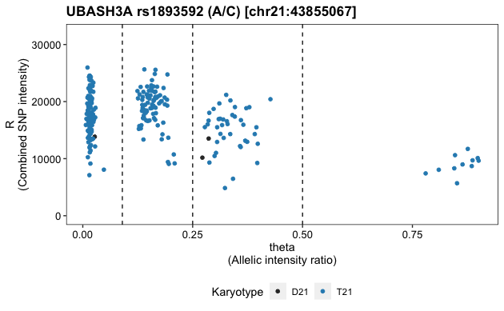

```r
# https://dnatech.genomecenter.ucdavis.edu/wp-content/uploads/2013/05/technote_infinium_genotyping_data_analysis.pdf
# x axis = theta
# y axis = R

HTP.idatData.29800833.rs1893592.ALL03 %>%
  rename(`R\n(Combined SNP intensity)` = `R (Combined SNP intensity)`,
         `theta\n(Allelic intensity ratio)` = `theta (Allelic intensity ratio)`) %>%
  ggplot(aes(x = `theta\n(Allelic intensity ratio)`,
             y = `R\n(Combined SNP intensity)`,
             color = Karyotype, fill = Karyotype)) +
  geom_point() +
  ggtitle(paste("UBASH3A ", plotName.rs1893592, sep = "")) +
  scale_colour_manual(values = c("gray20", GrayBlue[[2]])) +
  scale_fill_manual(values = c("gray20", GrayBlue[[2]])) +
  theme(legend.position = "bottom") +
  geom_vline(xintercept = 0.09, linetype = "dashed", color = "black") +
  geom_vline(xintercept = 0.25, linetype = "dashed", color = "black") +
  geom_vline(xintercept = 0.5, linetype = "dashed", color = "black") +
  ylim(0, 32000)
```

#### Based on the thresholds of theta identified visually above, define the genotype of each participant

```r
# Above we determined that the "A" allele for this SNP is A, and the "B" allele is C.
# rs1893592: Allele A = A (FWD), Allele B = C (FWD)

HTP.idatData.29800833.rs1893592.ALL04 <- HTP.idatData.29800833.rs1893592.ALL03 %>%
  mutate(Genotype = ifelse(Karyotype == "D21" & `theta (Allelic intensity ratio)`<0.09, "AA",
                           ifelse(Karyotype == "D21" & `theta (Allelic intensity ratio)`>0.09, "AC", # We will validate this below (not all genotype clusters were observed for the D21s genotyped on MEGA, so we can't be positive).
                                  ifelse(Karyotype == "T21" & `theta (Allelic intensity ratio)`<0.09, "AAA",
                                         ifelse(Karyotype == "T21" & `theta (Allelic intensity ratio)`>0.09 & `theta (Allelic intensity ratio)`<0.25, "AAC",
                                                ifelse(Karyotype == "T21" & `theta (Allelic intensity ratio)`>0.25 & `theta (Allelic intensity ratio)`<0.50, "ACC",
                                                       ifelse(Karyotype == "T21" & `theta (Allelic intensity ratio)`>0.5, "CCC", NA)))))))

HTP.idatData.29800833.rs1893592.ALL04
```

| MEGA.IID | MEGA.LabID | SentrixBarcode_A | SentrixPosition_A | Quants_rowname | SNP | R (Combined SNP intensity) | theta (Allelic intensity ratio) | Mean_Intensity.Grn | Mean_Intensity.Red | SD_Intensity.Grn | SD_Intensity.Red | NBeads_Intensity.Grn | NBeads_Intensity.Red | Sample_Plate | Sample_Well | Sample_Group | Gender | Replicate | Parent1 | Parent2 | Karyotype | Genotype |
| --- | --- | --- | --- | --- | --- | --- | --- | --- | --- | --- | --- | --- | --- | --- | --- | --- | --- | --- | --- | --- | --- | --- |
| WG2-DNA_B04_HTP0050A2 | HTP0050A2 | 203752160033 | R02C01 | 29800833 | rs1893592 | 19788 | 0.147948230 | 3787 | 16001 | 553 | 1993 | 19 | 19 | 2 | B04 | NA | Female | NA | NA | NA | T21 | AAC |
| WG2-DNA_C04_HTP0380A | HTP0380A | 203752160033 | R03C01 | 29800833 | rs1893592 | 21681 | 0.017184649 | 570 | 21111 | 186 | 926 | 9 | 9 | 2 | C04 | NA | Male | NA | NA | NA | T21 | AAA |
| WG2-DNA_D04_HTP0385A | HTP0385A | 203752160033 | R04C01 | 29800833 | rs1893592 | 22654 | 0.161157550 | 4656 | 17998 | 516 | 570 | 8 | 8 | 2 | D04 | NA | Male | NA | NA | NA | T21 | AAC |
| WG2-DNA_E04_HTP0053A2 | HTP0053A2 | 203752160033 | R05C01 | 29800833 | rs1893592 | 20822 | 0.165374597 | 4372 | 16450 | 735 | 1855 | 14 | 14 | 2 | E04 | NA | Female | NA | NA | NA | T21 | AAC |
| WG2-DNA_F04_HTP0374A | HTP0374A | 203752160033 | R06C01 | 29800833 | rs1893592 | 22739 | 0.016306028 | 568 | 22171 | 435 | 2055 | 13 | 13 | 2 | F04 | NA | Male | NA | NA | NA | T21 | AAA |
| WG2-DNA_G04_HTP0381A | HTP0381A | 203752160033 | R07C01 | 29800833 | rs1893592 | 22816 | 0.021927805 | 760 | 22056 | 499 | 1474 | 14 | 14 | 2 | G04 | NA | Male | NA | NA | NA | T21 | AAA |
| WG2-DNA_A09_HTP0409A | HTP0409A | 203752160056 | R01C01 | 29800833 | rs1893592 | 16969 | 0.014933635 | 389 | 16580 | 142 | 1547 | 17 | 17 | 2 | A09 | NA | Female | NA | NA | NA | T21 | AAA |
| WG2-DNA_B09_HTP0416A | HTP0416A | 203752160056 | R02C01 | 29800833 | rs1893592 | 15859 | 0.133388536 | 2781 | 13078 | 279 | 1838 | 11 | 11 | 2 | B09 | NA | Male | NA | NA | NA | T21 | AAC |
| WG2-DNA_C09_HTP0421A | HTP0421A | 203752160056 | R03C01 | 29800833 | rs1893592 | 16599 | 0.148187480 | 3181 | 13418 | 273 | 1604 | 11 | 11 | 2 | C09 | NA | Male | NA | NA | NA | T21 | AAC |
| WG2-DNA_D09_HTP0425A | HTP0425A | 203752160056 | R04C01 | 29800833 | rs1893592 | 17096 | 0.162060565 | 3530 | 13566 | 380 | 1484 | 14 | 14 | 2 | D09 | NA | Male | NA | NA | NA | T21 | AAC |

[output cut: 234 more lines]

```r
setwd(dir.GRSdata)
fwrite(HTP.idatData.29800833.rs1893592.ALL04, "MEGA_041422_chr21_UBASH3A_rs1893592_Manual_Genotypes_v0.1_JRS.csv")
```

#### Read in the chr21 SNP dosage data based on Illumina’s disomic genotype calling algorithm

```r
#list.files("/Users/shawjes/Dropbox/EspinosaGroup/ANALYSIS/Celiac_MultiOmics/GRS/DSMIG_Shared/Manuscript/Data")

# If an HTP LabID includes A, then the individual is T21
# If a HTP LabID includes B, then the individual is D21

setwd("/Users/shawjes/Dropbox/EspinosaGroup/ANALYSIS/Celiac_MultiOmics/GRS/DSMIG_Shared/Manuscript/Data")
dosage.disomic.rs1893592.D21s <- fread("MEGA_022322_CeliacGRS_35of38_nonHLADR_SNPs_v0.1_JRS.raw") %>%
  select(IID, rs1893592_C) %>%
  rename(MEGA.IID = IID) %>%
  filter(grepl("HTP", MEGA.IID)==TRUE) %>%
  mutate(temp = gsub("HTP", "|HTP", MEGA.IID)) %>%
  separate(temp, into = c("a", "LabID"), sep = "[|]") %>%
  select(-c(a)) %>%
  filter(grepl("B", LabID)==TRUE) %>%
  mutate(Variant = "rs1893592 (C)") %>%
  rename(Dosage.Disomic = rs1893592_C) %>%
  select(MEGA.IID, Variant, Dosage.Disomic) %>%
  mutate(Genotype.Disomic = ifelse(Dosage.Disomic == 0, "AA",
                                   ifelse(Dosage.Disomic == 1, "CA",
                                          ifelse(Dosage.Disomic == 2, "CC", NA)))) %>%
  mutate(Karyotype = "D21") %>%
  select(MEGA.IID, Karyotype, Variant, everything()) %>%
  unique()

setwd("/Users/shawjes/Dropbox/EspinosaGroup/ANALYSIS/Celiac_MultiOmics/GRS/DSMIG_Shared/Manuscript/Data")
dosage.disomic.rs1893592.T21s <- fread("MEGA_022322_AnalysisDataset_GRS_v0.1_JRS.csv") %>%
  filter(MEGA.CHR == 21 & grepl("rs1893592", Variant)==TRUE) %>%
  select(FamilyID, RecordID, MEGA.IID, MEGA.LabID, Karyotype, Variant, Dosage) %>%
  unique() %>%
  rename(Dosage.Disomic = Dosage) %>%
  mutate(Genotype.Disomic = ifelse(Dosage.Disomic == 0, "AA",
                                   ifelse(Dosage.Disomic == 1, "CA",
                                          ifelse(Dosage.Disomic == 2, "CC", NA)))) %>%
  select(MEGA.IID, Variant, Dosage.Disomic, Genotype.Disomic) %>%
  mutate(Karyotype = "T21") %>%
  select(MEGA.IID, Karyotype, Variant, everything()) %>%
  unique()

dosage.disomic.rs1893592 <- rbind(dosage.disomic.rs1893592.D21s,
                                  dosage.disomic.rs1893592.T21s) %>%
  unique()

dosage.disomic.rs1893592.D21s
```

| MEGA.IID | Karyotype | Variant | Dosage.Disomic | Genotype.Disomic |
| --- | --- | --- | --- | --- |
| WG3-DNA_B05_HTP0498B | D21 | rs1893592 (C) | 1 | CA |
| WG3-DNA_G05_HTP0496B | D21 | rs1893592 (C) | 1 | CA |
| WG3-DNA_H05_HTP0497B | D21 | rs1893592 (C) | 0 | AA |

```r
dosage.disomic.rs1893592.T21s
```

| MEGA.IID | Karyotype | Variant | Dosage.Disomic | Genotype.Disomic |
| --- | --- | --- | --- | --- |
| WG1-DNA_B01_HTP0207A | T21 | rs1893592 (C) | 0 | AA |
| WG1-DNA_D01_HTP0222A | T21 | rs1893592 (C) | 1 | CA |
| WG1-DNA_E01_HTP0442A | T21 | rs1893592 (C) | 1 | CA |
| WG1-DNA_F01_HTP0219A | T21 | rs1893592 (C) | 1 | CA |
| WG1-DNA_G01_HTP0465A | T21 | rs1893592 (C) | 1 | CA |
| WG1-DNA_H01_HTP0119A | T21 | rs1893592 (C) | 1 | CA |
| WG1-DNA_B02_HTP0223A | T21 | rs1893592 (C) | 1 | CA |
| WG1-DNA_C02_HTP0471A | T21 | rs1893592 (C) | 2 | CC |
| WG1-DNA_D02_HTP0213A | T21 | rs1893592 (C) | 1 | CA |
| WG1-DNA_E02_HTP0220A | T21 | rs1893592 (C) | 0 | AA |

[output cut: 191 more lines]

```r
dosage.disomic.rs1893592
```

| MEGA.IID | Karyotype | Variant | Dosage.Disomic | Genotype.Disomic |
| --- | --- | --- | --- | --- |
| WG3-DNA_B05_HTP0498B | D21 | rs1893592 (C) | 1 | CA |
| WG3-DNA_G05_HTP0496B | D21 | rs1893592 (C) | 1 | CA |
| WG3-DNA_H05_HTP0497B | D21 | rs1893592 (C) | 0 | AA |
| WG1-DNA_B01_HTP0207A | T21 | rs1893592 (C) | 0 | AA |
| WG1-DNA_D01_HTP0222A | T21 | rs1893592 (C) | 1 | CA |
| WG1-DNA_E01_HTP0442A | T21 | rs1893592 (C) | 1 | CA |
| WG1-DNA_F01_HTP0219A | T21 | rs1893592 (C) | 1 | CA |
| WG1-DNA_G01_HTP0465A | T21 | rs1893592 (C) | 1 | CA |
| WG1-DNA_H01_HTP0119A | T21 | rs1893592 (C) | 1 | CA |
| WG1-DNA_B02_HTP0223A | T21 | rs1893592 (C) | 1 | CA |

[output cut: 194 more lines]

#### For the 3 D21 individuals genotyped on MEGA, compare the genotype called by Illumina’s standard disomic genotyping algorithm to the genotype we’ve assigned them manually above

```r
D21.trueGenotype_vs_manualGenotype <- HTP.idatData.29800833.rs1893592.ALL04 %>%
  filter(Karyotype == "D21") %>%
  rename(Variant = SNP,
         Genotype.MANUAL = Genotype) %>%
  select(MEGA.IID, Karyotype, Variant, Genotype.MANUAL) %>%
  mutate(Variant = paste(Variant, " (C)", sep = "")) %>%
  full_join(dosage.disomic.rs1893592.D21s %>%
              filter(Karyotype == "D21") %>%
              select(MEGA.IID, Karyotype, Variant, Genotype.Disomic) %>%
              mutate(Genotype.Disomic = gsub("CA", "AC", Genotype.Disomic)),
            by = c("MEGA.IID", "Karyotype", "Variant")) %>%
  rename(True_Genotype = Genotype.Disomic,
         Manual_Genotype = Genotype.MANUAL) %>%
  mutate(TrueGenotype_matches_ManualGenotype = ifelse(Manual_Genotype == Manual_Genotype, "Yes", "No"))

D21.trueGenotype_vs_manualGenotype
```

| MEGA.IID | Karyotype | Variant | Manual_Genotype | True_Genotype | TrueGenotype_matches_ManualGenotype |
| --- | --- | --- | --- | --- | --- |
| WG3-DNA_B05_HTP0498B | D21 | rs1893592 (C) | AC | AC | Yes |
| WG3-DNA_G05_HTP0496B | D21 | rs1893592 (C) | AC | AC | Yes |
| WG3-DNA_H05_HTP0497B | D21 | rs1893592 (C) | AA | AA | Yes |

#### Take a peek at this SNP’s association with Celiac (too excited…)

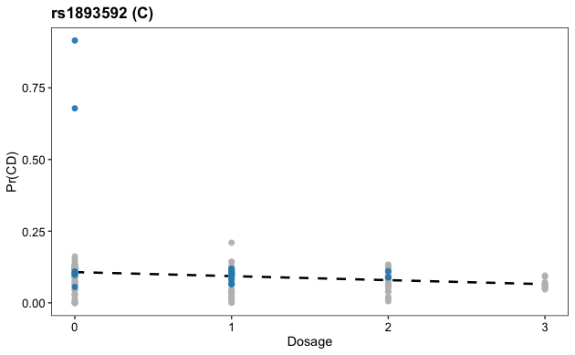

```r
ggplot() +
  geom_smooth(aes(x = Dosage.GRS_risk_allele, y = `Pr(CD)`), se = FALSE, color = "black", data = plotData.probabilityCD, method = "lm", linetype = "dashed") +
  geom_point(aes(x = Dosage.GRS_risk_allele, y = `Pr(CD)`), data = (plotData.probabilityCD %>% filter(Celiac == 0)), color = GrayBlue[[1]], fill = GrayBlue[[1]], alpha = 0.95, size = 2) +
  geom_point(aes(x = Dosage.GRS_risk_allele, y = `Pr(CD)`), data = (plotData.probabilityCD %>% filter(Celiac == 1)), color = GrayBlue[[2]], fill = GrayBlue[[2]], alpha = 0.95, size = 2) +
  scale_colour_manual(values = GrayBlue) +
  scale_fill_manual(values = GrayBlue) +
  theme(legend.position = "bottom",
        legend.title = element_blank()) +
  xlab("Dosage") +
  labs(title = element_text(paste(chr21UBASH3Asnp_vs_CD$SNP[1], " (", chr21UBASH3Asnp_vs_CD$GRS_risk_allele[1], ")", sep = "")))
```

```r
setwd("/Users/shawjes/Dropbox/EspinosaGroup/DATA_MAIN/MEGA/chr21_genotyping/idatQuants")
HTP.idatData <- readRDS(file = "MEGA_041422_idat_Quants_all_v0.1_JRS.rds")

HTP.idatData
```